# Data Visualization Project

by smurfs

May 19, 2019

# Project description

Given are the color specifications for 64 colors arranged in an $8 \times 8$ grid. The master specifications in the Lab scale for these colors are provided in the `MasterColorCard.csv` file. On one sheet, this grid is printed 42 times in a $7 \times 6$ layout. There are 13 of these sheets. The $64 \times 7 \times 6 \times 13$ Lab values of these colors are provided in the `LabMeasurements-Color-Card.csv` file. Using Data Visualization principles, the task of the project is to compare how the Lab values in the sheets compare with the master values.

$$\begin{eqnarray}
\Delta L &=& L_{\rm measured} - L_{\rm master} \nonumber \\
\Delta a &=& a_{\rm measured} - a_{\rm master} \nonumber \\
\Delta b &=& b_{\rm measured} - b_{\rm master} \nonumber \\
\Delta E &=& \sqrt{\Delta L^2 + \Delta a^2 + \Delta b^2}
\end{eqnarray}$$

# 1. Data processing

## 1a. Find the $\Delta$ values

We process the data first by replacing the L, a and b values by $\Delta L$, $\Delta a$ and $\Delta b$. For this we write the following function.

```r
setwd("/home/kbhaskar/beuth/Semester2/DataVisualization/Project1")

mcc <- read.csv2("MasterColorCard.csv")
lcc <- read.csv2("LabMeasurements-Color-Card.csv")

# Add the sheet number
lcc$Sheet <- rep(1:13 , 42)

#function for calculating delta_L, delta_a and delta_b
find_delta_Lab <- function() {


  lcc_color_cols <- names(lcc)[!(names(lcc) %in% c("Row","Column","Sheet"))]

  # find delta_L = L_lab - L_master, delta_a = a_lab - a_master and delta_b = b_lab - b_master
  lcc_deltas <- lcc
  count <- 0L
  for (color_col in lcc_color_cols) {
    row_number <- 1L + (as.integer(count) %/% 3L) #this assigns the correct row in the mcc.
    column_number <- 1L + (as.integer(count) %% 3L)#this assigns the correct column.
    Lab_column <- c("L","a","b")[column_number]
    lcc_deltas[[color_col]] <- lcc[[color_col]] - mcc[[Lab_column]][row_number]
    count <- count + 1L
  }
  return(lcc_deltas)
}

lcc_deltas <- find_delta_Lab()

# The columns of lcc_deltas contains the delta_L, delta_a and delta_b for each color.
```

## 1b. Change from wide to long format

```r
require(reshape)
lcc_deltas_long <- melt(lcc_deltas , id = c("Row","Column","Sheet"))
names(lcc_deltas_long) <- c("Row" , "Column" , "Sheet" , "Color" ,  "Delta")
# contains delta values in long format. Has 64*42*13*3 rows.
detach(package:reshape)

L_deltas <- lcc_deltas_long[  grepl("L" , lcc_deltas_long$Color)   , ]
a_deltas <- lcc_deltas_long[  grepl("a" , lcc_deltas_long$Color)   , ]
b_deltas <- lcc_deltas_long[  grepl("b" , lcc_deltas_long$Color)   , ]

L_deltas$Color <- as.character(L_deltas$Color)
a_deltas$Color <- as.character(a_deltas$Color)
b_deltas$Color <- as.character(b_deltas$Color)

names(L_deltas) <- c("Row", "Column", "Sheet", "Color",  "Delta_L")
names(a_deltas) <- c("Row", "Column", "Sheet", "Color",  "Delta_a")
names(b_deltas) <- c("Row", "Column", "Sheet", "Color",  "Delta_b")

Lab_deltas <- L_deltas
Lab_deltas$Color <- gsub("L" , "color" , Lab_deltas$Color)
Lab_deltas$Delta_a <- a_deltas$Delta_a
Lab_deltas$Delta_b <- b_deltas$Delta_b

Lab_deltas$Delta_E <- sqrt(Lab_deltas$Delta_L^2 + Lab_deltas$Delta_a^2 + Lab_deltas$Delta_b^2)
Lab_deltas$colorIndex <- rep(1:64 , each = 546)
```

```r
#Lab_deltas[1:130 , ]
dim(Lab_deltas)
```

```
## [1] 34944     9
```

# 2. Plotting

## 2a. $\Delta E$ for each color

First we calculate the mean $\Delta E$ for each color averaged over all the cards and the sheets and plot these values.

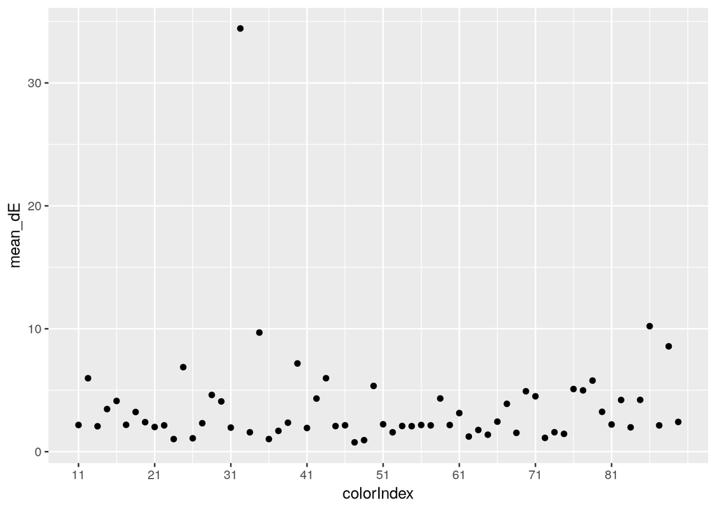

```r
library(dplyr)
by_color <- group_by(Lab_deltas , Color)
dE_by_color <- as.data.frame(summarize(by_color , mean(Delta_E)))
names(dE_by_color) <- c("Color" , "mean_dE")
dE_by_color$colorIndex <- 1:64
detach(package:dplyr)
#dE_by_color
require(ggplot2)
ggplot(data=dE_by_color , aes(x=colorIndex , y=mean_dE)) + geom_point(
) + scale_x_continuous(breaks=seq(1,64,8),labels=paste0(c(1:8) , 1))
```

The above picture shows that the color 32 is an outlier. We can see if this aberrant behavior is consistent over all the cards and sheets or if only some cards have an extremely high value by plotting all the $\Delta E$ (instead of just the mean) with a transparency.

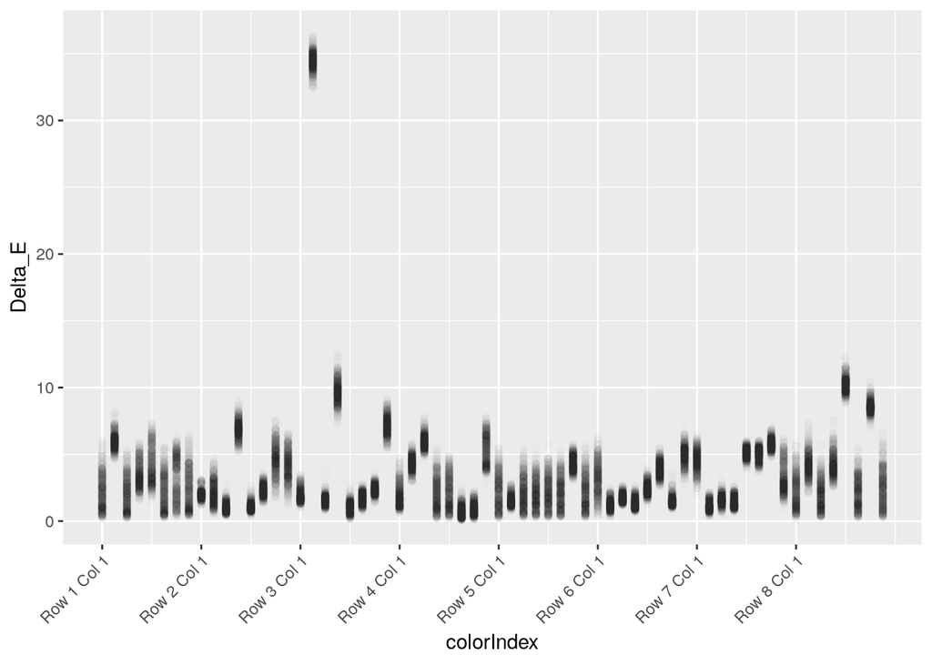

```r
ggplot(data=Lab_deltas , aes(x=colorIndex , y = Delta_E)) + geom_point(alpha = 0.01
) + scale_x_continuous(breaks=seq(1,64,8),labels=paste0("Row ",c(1:8) , " Col ", 1)) + theme(axis.text.x = element_text(angle=45,hjust=1))
```

The same point can be illustrated by a heat map.

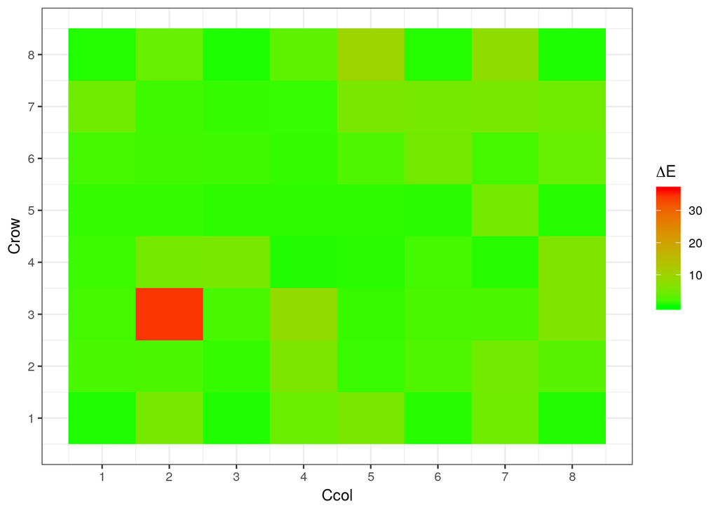

```r
#head(Lab_deltas)
#Lab_deltas$colorIndex[1:1500]
#unique(Lab_deltas$colorIndex)
Lab_deltas$colorIndexRow <- rep(1:8 , each = 546*8)
Lab_deltas$colorIndexCol <- rep(rep(1:8 , each = 546) , times = 8)
ggplot(data = Lab_deltas , aes(x=colorIndexCol , y=colorIndexRow , fill = Delta_E)) + geom_tile()+scale_fill_gradient(low="green",high="red", name = expression(Delta*E))+theme_bw()+labs(x="Ccol",y="Crow"
) + scale_x_continuous(breaks = 1:8) + scale_y_continuous(breaks = 1:8)
```

Hence it is best to omit this particular color since its behavior dominates over all other colors.

```r
head(Lab_deltas)
```

```
##   Row Column Sheet   Color Delta_L Delta_a Delta_b  Delta_E colorIndex
## 1   1      1     1 color11  3.9459 -0.0338 -0.8689 4.040576          1
## 2   1      1     2 color11  4.9647 -0.0725 -1.0272 5.070369          1
## 3   1      1     3 color11  4.1410 -0.1015 -0.9423 4.248072          1
## 4   1      1     4 color11  3.0942 -0.0448 -1.0832 3.278628          1
## 5   1      1     5 color11  4.1079 -0.0754 -1.0403 4.238249          1
## 6   1      1     6 color11  4.7165 -0.0385 -1.0092 4.823416          1
##   colorIndexRow colorIndexCol
## 1             1             1
## 2             1             1
## 3             1             1
## 4             1             1
## 5             1             1
## 6             1             1
```

```r
mean(Lab_deltas$Delta_E[Lab_deltas$colorIndexRow==3 & Lab_deltas$colorIndexCol==2])
```

```
## [1] 34.43232
```

## Omit the color 32

```r
Lab_deltas <- Lab_deltas[Lab_deltas$colorIndexRow!=3 | Lab_deltas$colorIndexCol!=2 , ]
#Lab_deltas$colorIndexRow <- as.character(Lab_deltas$colorIndexRow)
#Lab_deltas$colorIndexCol <- as.character(Lab_deltas$colorIndexCol)
```

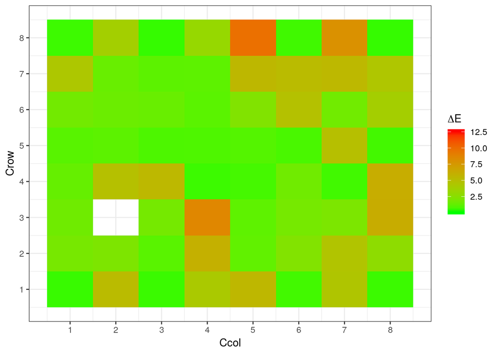

```r
ggplot(data = Lab_deltas , aes(x=colorIndexCol , y=colorIndexRow , fill = Delta_E)) + geom_tile()+scale_fill_gradient(low="green",high="red", name = expression(Delta*E))+theme_bw()+labs(x="Ccol",y="Crow"
) + scale_x_continuous(breaks = (1:8)) + scale_y_continuous(breaks = (1:8))
```

```r
#unique(Lab_deltas$Color)
```

The above picture is not particularly revealing. However, it does show that if we start at the bottom left corner and move right till we reach the end of the row, then start again on the left most square on the upper row and move right till we reach the end of this row, and so on till we reach the top right corner - moving in this sequence and numbering the squares in this sequence from 1 till 63 (not 64 - because we skipped the 32 color, and the sequence corresponds to `color11`, color12`, color13`, …. , `color21`, color22`, color23`, …. , etc. - first index is for `Crow` and second is for `Ccol`), we see that the color 19 has a slightly high value and so do the colors 60 and 62.

So let us take the 63 colors and plot the mean delta E for each of the 42 positions averaged over all the 13 sheets.

```r
require(dplyr)
by_RowColumnColor <- group_by(Lab_deltas , Row, Column , Color)
dE_by_RowColumnColor <- as.data.frame(summarize(by_RowColumnColor , mean(Delta_E)))
dE_by_RowColumnColor$CardIndex <- rep(1:42 , each = 63)
dE_by_RowColumnColor$ColorIndex <- rep(1:63 , times = 42)
head(dE_by_RowColumnColor)
```

```
##   Row Column   Color mean(Delta_E) CardIndex ColorIndex
## 1   1      1 color11      4.169264         1          1
## 2   1      1 color12      6.707204         1          2
## 3   1      1 color13      3.570036         1          3
## 4   1      1 color14      2.525880         1          4
## 5   1      1 color15      2.550091         1          5
## 6   1      1 color16      4.105192         1          6
```

```r
names(dE_by_RowColumnColor) <- c("Row" , "Column" , "Color" , "mean_Delta_E" , "CardIndex" , "ColorIndex")
```

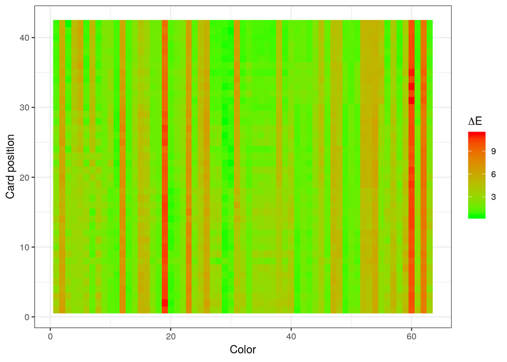

```r
ggplot(data = dE_by_RowColumnColor , aes(x=ColorIndex , y=CardIndex , fill = mean_Delta_E)) + geom_tile()+scale_fill_gradient(low="green",high="red", name = expression(Delta*E))+theme_bw()+labs(x="Color",y="Card position"
)# + scale_x_continuous(breaks = (1:8)) + scale_y_continuous(breaks = (1:8))
```

This picture sheds insight on the deviant behavior of colors 19, 60 and 62. It shows that these colors are uniformly high across all the card positions.

# How these 3 colors behave across the $42 \times 13$ grid - we need 3 heat maps.

```r
Lab_deltas_34 <- Lab_deltas[Lab_deltas$Color == "color34" , ]
Lab_deltas_85 <- Lab_deltas[Lab_deltas$Color == "color85" , ]
Lab_deltas_87 <- Lab_deltas[Lab_deltas$Color == "color87" , ]
```

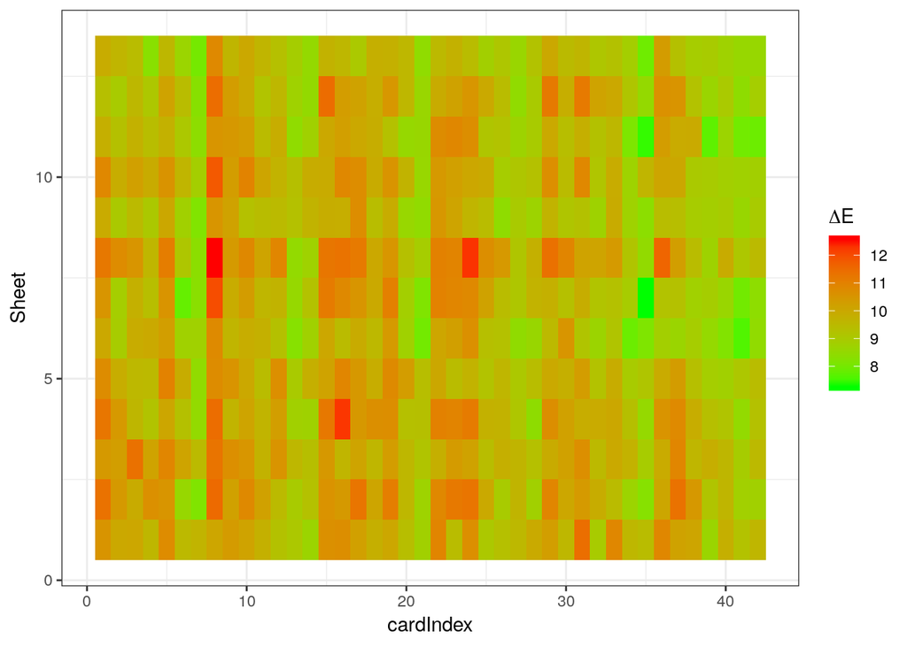

```r
Lab_deltas_34$cardIndex <- rep(1:42 , each = 13)
ggplot(data = Lab_deltas_34 , aes(x=cardIndex , y=Sheet , fill = Delta_E)) + geom_tile()+scale_fill_gradient(low="green",high="red", name = expression(Delta*E),limits=c(min(Lab_deltas_34$Delta_E),max(Lab_deltas_34$Delta_E)))+theme_bw()#+labs(x="Color",y="Card position")
```

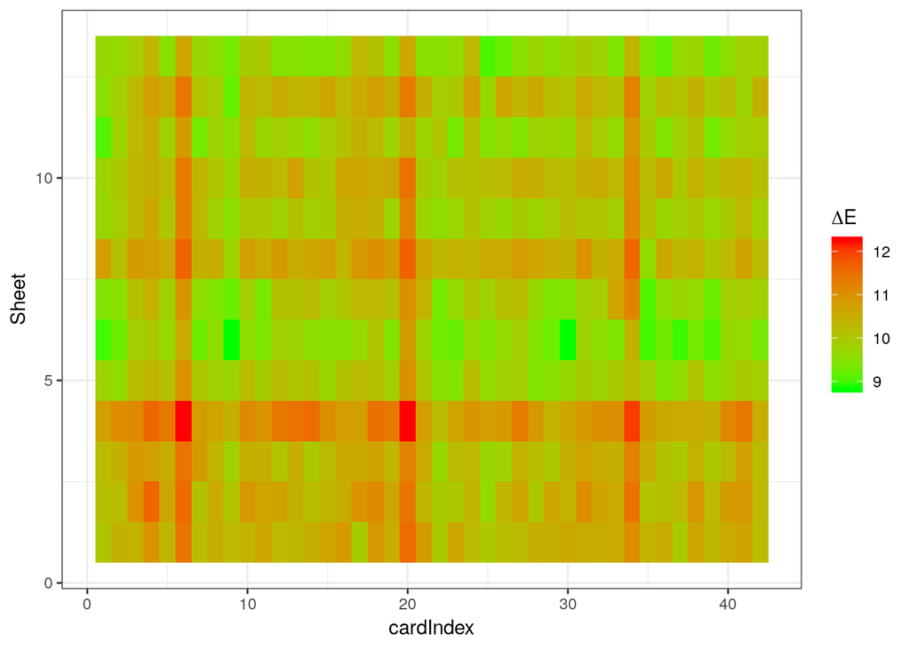

```r
Lab_deltas_85$cardIndex <- rep(1:42 , each = 13)
ggplot(data = Lab_deltas_85 , aes(x=cardIndex , y=Sheet , fill = Delta_E)) + geom_tile()+scale_fill_gradient(low="green",high="red", name = expression(Delta*E),limits=c(min(Lab_deltas_85$Delta_E),max(Lab_deltas_85$Delta_E)))+theme_bw()#+labs(x="Color",y="Card position")
```

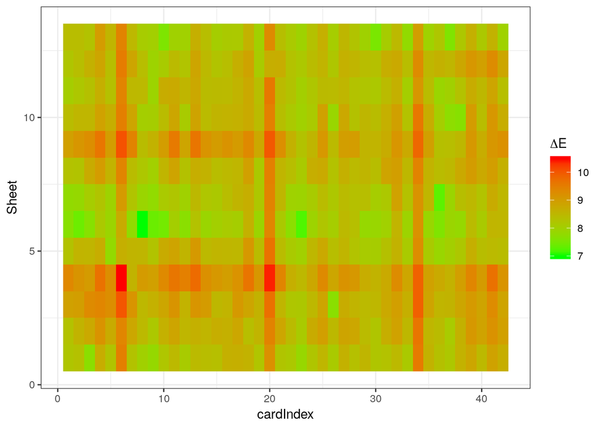

```r
Lab_deltas_87$cardIndex <- rep(1:42 , each = 13)
ggplot(data = Lab_deltas_87 , aes(x=cardIndex , y=Sheet , fill = Delta_E)) + geom_tile()+scale_fill_gradient(low="green",high="red", name = expression(Delta*E),limits=c(min(Lab_deltas_87$Delta_E),max(Lab_deltas_87$Delta_E)))+theme_bw()#+labs(x="Color",y="Card position")
```

# Further plots

```r
Lab_deltas_34$theta <- (180.0/pi)*acos(Lab_deltas_34$Delta_L / Lab_deltas_34$Delta_E)
Lab_deltas_34$phi   <- (180.0/pi)*acos(Lab_deltas_34$Delta_a / sqrt(Lab_deltas_34$Delta_a^2 + Lab_deltas_34$Delta_b^2))
```

```r
Lab_deltas_85$theta <- (180.0/pi)*acos(Lab_deltas_85$Delta_L / Lab_deltas_85$Delta_E)
Lab_deltas_85$phi   <- (180.0/pi)*acos(Lab_deltas_85$Delta_a / sqrt(Lab_deltas_85$Delta_a^2 + Lab_deltas_85$Delta_b^2))
```

```r
Lab_deltas_87$theta <- (180.0/pi)*acos(Lab_deltas_87$Delta_L / Lab_deltas_87$Delta_E)
Lab_deltas_87$phi   <- (180.0/pi)*acos(Lab_deltas_87$Delta_a / sqrt(Lab_deltas_87$Delta_a^2 + Lab_deltas_87$Delta_b^2))
```

```r
#- here you need to make the correction for the 3rd, 4th, 7th and 8th octants----

aNbN <- Lab_deltas_34$Delta_a < 0 & Lab_deltas_34$Delta_b < 0
aPbN <- Lab_deltas_34$Delta_a > 0 & Lab_deltas_34$Delta_b < 0
Lab_deltas_34$phi[aNbN] <- Lab_deltas_34$phi[aNbN] + 2*(180-Lab_deltas_34$phi[aNbN])
Lab_deltas_34$phi[aPbN] <- 180*pi - Lab_deltas_34$phi[aPbN]

aNbN <- Lab_deltas_85$Delta_a < 0 & Lab_deltas_85$Delta_b < 0
aPbN <- Lab_deltas_85$Delta_a > 0 & Lab_deltas_85$Delta_b < 0
Lab_deltas_85$phi[aNbN] <- Lab_deltas_85$phi[aNbN] + 2*(180-Lab_deltas_85$phi[aNbN])
Lab_deltas_85$phi[aPbN] <- 2*180 - Lab_deltas_85$phi[aPbN]

aNbN <- Lab_deltas_87$Delta_a < 0 & Lab_deltas_87$Delta_b < 0
aPbN <- Lab_deltas_87$Delta_a > 0 & Lab_deltas_87$Delta_b < 0
Lab_deltas_87$phi[aNbN] <- Lab_deltas_87$phi[aNbN] + 2*(180-Lab_deltas_87$phi[aNbN])
Lab_deltas_87$phi[aPbN] <- 2*180 - Lab_deltas_87$phi[aPbN]

#--------------------------------------------------------------------------------
```

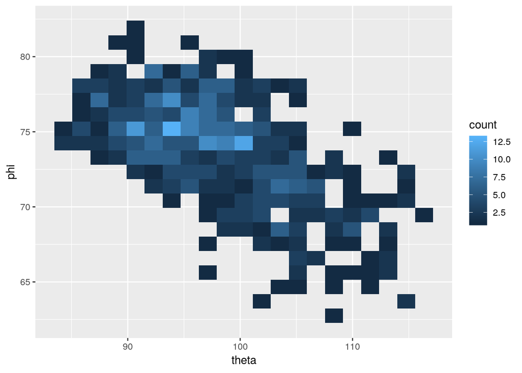

```r
ggplot(data=Lab_deltas_34 , aes(x=theta , y=phi)) + geom_bin2d(bins=20)
```

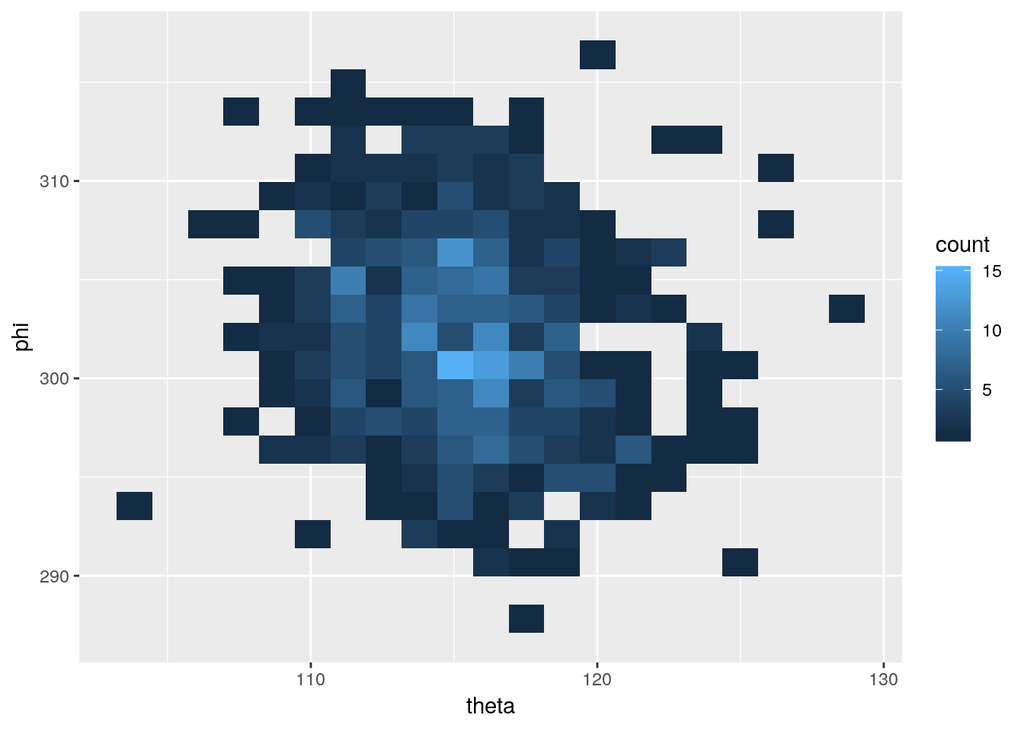

```r
ggplot(data=Lab_deltas_85 , aes(x=theta , y=phi)) + geom_bin2d(bins=20)
```

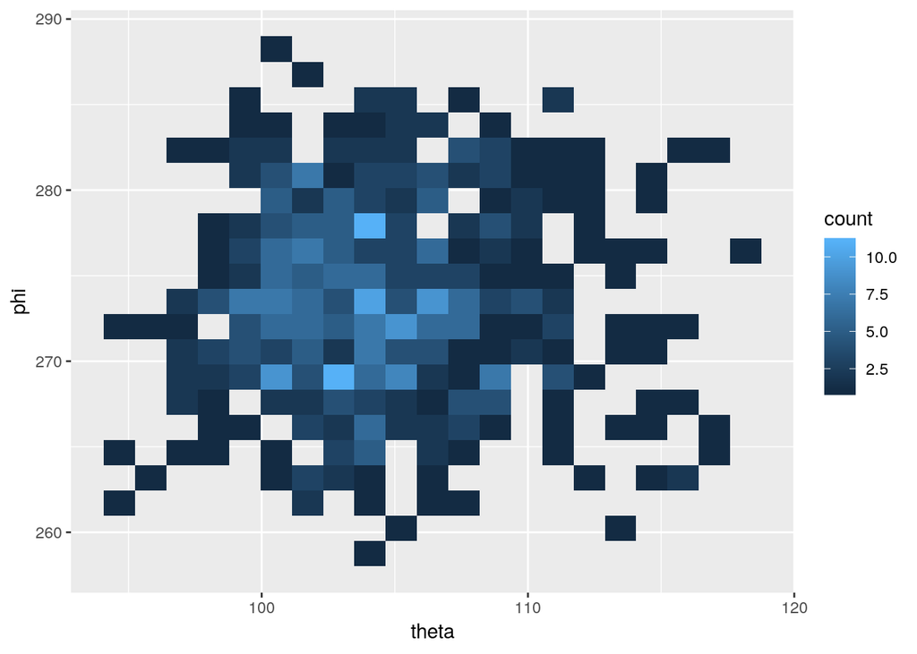

```r
ggplot(data=Lab_deltas_87 , aes(x=theta , y=phi)) + geom_bin2d(bins=20)
```

# Trying out rgl

```r
R <- 1
Lab_deltas_34$xUnit <- R*sin((pi/180)*Lab_deltas_34$theta)*cos((pi/180)*Lab_deltas_34$phi)
Lab_deltas_34$yUnit <- R*sin((pi/180)*Lab_deltas_34$theta)*sin((pi/180)*Lab_deltas_34$phi)
Lab_deltas_34$zUnit <- R*cos((pi/180)*Lab_deltas_34$theta)
Lab_deltas_85$xUnit <- R*sin((pi/180)*Lab_deltas_85$theta)*cos((pi/180)*Lab_deltas_85$phi)
Lab_deltas_85$yUnit <- R*sin((pi/180)*Lab_deltas_85$theta)*sin((pi/180)*Lab_deltas_85$phi)
Lab_deltas_85$zUnit <- R*cos((pi/180)*Lab_deltas_85$theta)
Lab_deltas_87$xUnit <- R*sin((pi/180)*Lab_deltas_87$theta)*cos((pi/180)*Lab_deltas_87$phi)
Lab_deltas_87$yUnit <- R*sin((pi/180)*Lab_deltas_87$theta)*sin((pi/180)*Lab_deltas_87$phi)
Lab_deltas_87$zUnit <- R*cos((pi/180)*Lab_deltas_87$theta)
```

# added by Pallavi

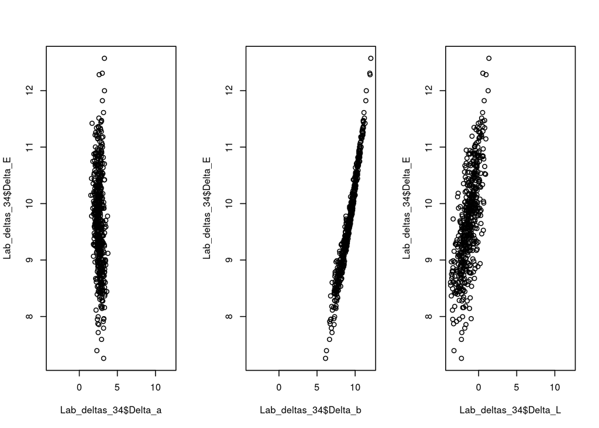

```r
par(mfrow= c(1,3))

plot(Lab_deltas_34$Delta_a, Lab_deltas_34$Delta_E, xlim = range(c(Lab_deltas_34$Delta_a, Lab_deltas_34$Delta_b, Lab_deltas_34$Delta_L)))
plot(Lab_deltas_34$Delta_b, Lab_deltas_34$Delta_E,  xlim = range(c(Lab_deltas_34$Delta_a, Lab_deltas_34$Delta_b, Lab_deltas_34$Delta_L)))
plot(Lab_deltas_34$Delta_L, Lab_deltas_34$Delta_E, xlim = range(c(Lab_deltas_34$Delta_a, Lab_deltas_34$Delta_b, Lab_deltas_34$Delta_L)))
```

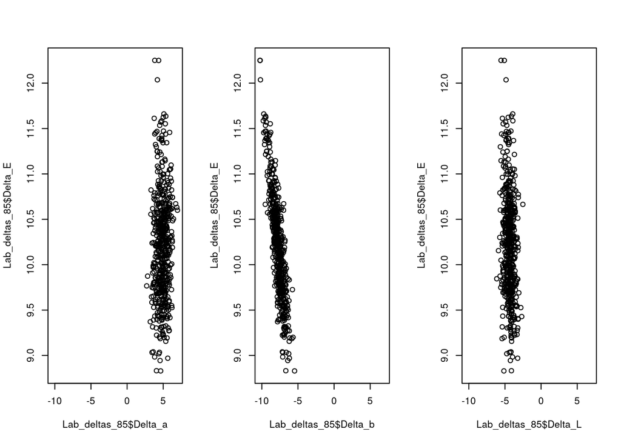

```r
par(mfrow= c(1,3))

plot(Lab_deltas_85$Delta_a, Lab_deltas_85$Delta_E, xlim = range(c(Lab_deltas_85$Delta_a, Lab_deltas_85$Delta_b, Lab_deltas_85$Delta_L)))
plot(Lab_deltas_85$Delta_b, Lab_deltas_85$Delta_E,  xlim = range(c(Lab_deltas_85$Delta_a, Lab_deltas_85$Delta_b, Lab_deltas_85$Delta_L)))
plot(Lab_deltas_85$Delta_L, Lab_deltas_85$Delta_E, xlim = range(c(Lab_deltas_85$Delta_a, Lab_deltas_85$Delta_b, Lab_deltas_85$Delta_L)))
```

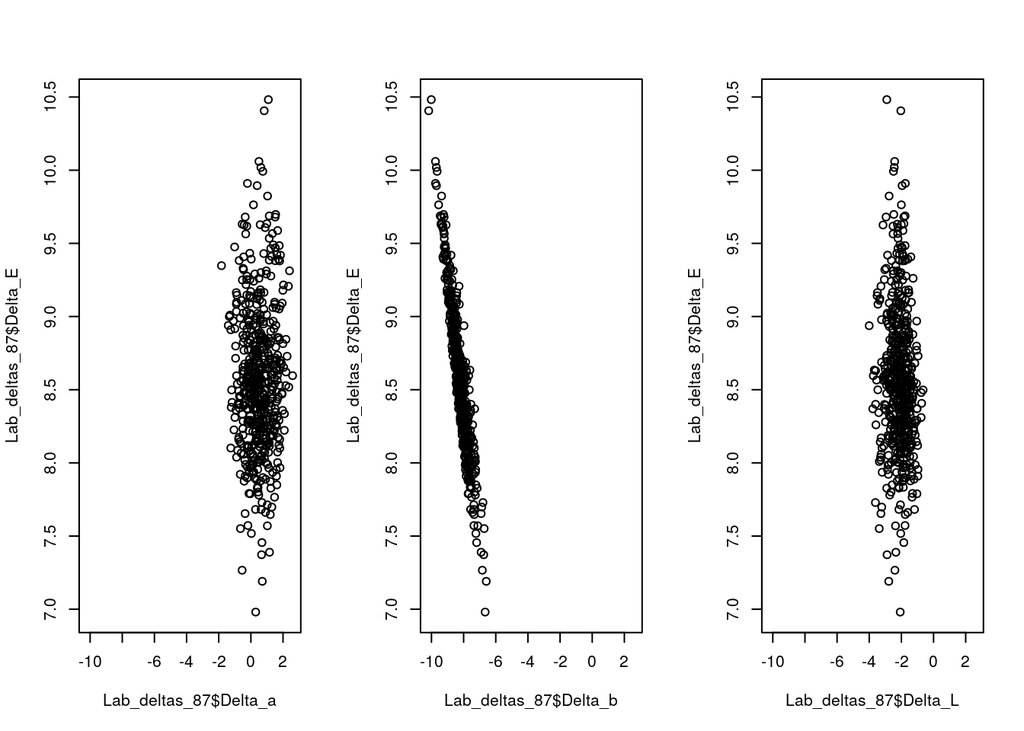

```r
par(mfrow= c(1,3))

plot(Lab_deltas_87$Delta_a, Lab_deltas_87$Delta_E, xlim = range(c(Lab_deltas_87$Delta_a, Lab_deltas_87$Delta_b, Lab_deltas_87$Delta_L)))
plot(Lab_deltas_87$Delta_b, Lab_deltas_87$Delta_E,  xlim = range(c(Lab_deltas_87$Delta_a, Lab_deltas_87$Delta_b, Lab_deltas_87$Delta_L)))
plot(Lab_deltas_87$Delta_L, Lab_deltas_87$Delta_E, xlim = range(c(Lab_deltas_87$Delta_a, Lab_deltas_87$Delta_b, Lab_deltas_87$Delta_L)))
```

# Conclusions

- The color at position `Crow = 3, Ccol = 2` was an extreme outlier in all the cards and sheets. The colors at positions `Crow = 3, Ccol = 4`, `Crow = 8, Ccol = 5`, and `Crow = 8, Ccol = 7` were also deviating consistently across all the 42 cards averaged over the 13 sheets. It was not like only some cards had a very high deviation for these colors.
- The person responsible for the printing has probably given the wrong values of L, a and b for these colors.
- The two dimensional histograms show in which octant the deltas lie, so we know in which direction the errors for a, L and b are.

# Appendix

```
require(rgl)
#https://stackoverflow.com/questions/39778093/how-to-increase-smoothness-of-spheres3d-in-rgl
sphere1.f <- function(x0 = 0, y0 = 0, z0 = 0, r = 1, n = 101, ...){
  f <- function(s,t){
    cbind(   r * cos(t)*cos(s) + x0,
             r *        sin(s) + y0,
             r * sin(t)*cos(s) + z0)
  }
  persp3d(f, slim = c(-pi/2,pi/2), tlim = c(0, 2*pi), n = n, add = T, ...)
}





rgl_add_axes <- function(x, y, z, axis.col = "grey",
                         xlab = "", ylab="", zlab="", show.plane = TRUE,
                         show.bbox = FALSE, bbox.col = c("#333377","black"))
{

  lim <- function(x){c(-max(abs(x)), max(abs(x))) * 1.1}
  # Add axes
  xlim <- lim(x); ylim <- lim(y); zlim <- lim(z)
  rgl.lines(xlim, c(0, 0), c(0, 0), color = axis.col)
  rgl.lines(c(0, 0), ylim, c(0, 0), color = axis.col)
  rgl.lines(c(0, 0), c(0, 0), zlim, color = axis.col)

  # Add a point at the end of each axes to specify the direction
  axes <- rbind(c(xlim[2], 0, 0), c(0, ylim[2], 0),
                c(0, 0, zlim[2]))
  rgl.points(axes, color = axis.col, size = 3)

  # Add axis labels
  rgl.texts(axes, text = c(xlab, ylab, zlab), color = axis.col,
            adj = c(0.5, -0.8), size = 2)

  # Add plane
  if(show.plane)
    xlim <- xlim/1.1; zlim <- zlim /1.1
  rgl.quads( x = rep(xlim, each = 2), y = c(0, 0, 0, 0),
```

[output cut: 44 more lines]

```
y <- Lab_deltas_85$yUnit
z <- Lab_deltas_85$zUnit
for (i in 1:length(x)) {
  rgl.lines(c(0,y[i]),c(0,z[i]),c(0,x[i]),color="yellow")
}
rgl.points(y,z,x,color="black")


x <- Lab_deltas_87$xUnit
y <- Lab_deltas_87$yUnit
z <- Lab_deltas_87$zUnit
for (i in 1:length(x)) {
  rgl.lines(c(0,y[i]),c(0,z[i]),c(0,x[i]),color="blue")
}
rgl.points(y,z,x,color="black")
```